# infusionsoft_interview

### Learning Paritions

Now that we have a structured and well-defined data frame, we need to split it into learning partitions for inference and modeling. I will partition the data into a training set, a test set, and a validation set. All exploratory data analysis, inference, and modeling will be performed on the training test. Different methods can we evaluated using cross validation and the test set. My final choice of model will be applied to the validation set.

```r
# clear workspace
rm(df, loan_df, glm_df, glm_bag, missing, cor_missing, check_missing)

# learning partitions -------------------------------------------------------------------------

set.seed(456)

# set up names and partition sizes
partition = c(train = .6, test = .2, validation = .2)

# split data set into train, test, validation
loan_splits = sample(cut(
  seq(nrow(loan_eda)),
  nrow(loan_eda)*cumsum(c(0,partition)),
  labels = names(partition)
))

# fracture the loan df dataset
dfs <- split(loan_eda, loan_splits)

# check resuts
sapply(dfs, nrow) / nrow(loan_eda)
```

```
##      train       test validation
##        0.6        0.2        0.2
```

```r
dim(dfs$train)
```

```
## [1] 82221    62
```

```r
# convert to data frame for modeling
# datasets will have response
dfs <- map(dfs, as.data.frame)
```

### Exploratory Data Analysis

This section reviews my process for manually exploring the data set as well as implementing automated feature importance and variable selection for inference before modeling.

First I examine the variables correlated with each other to see if any stick out as going against my loan default intuition. Based on the correlation plot there are quite a few variables that are correlated with each other.

Next I tried out a Learning Vector Quantization (LVQ) model to estimate the variable importance of our features. This is a supervised classification algorithm that we can then calculate variable importance from. This model should give us insight into which variables are most related to our response.

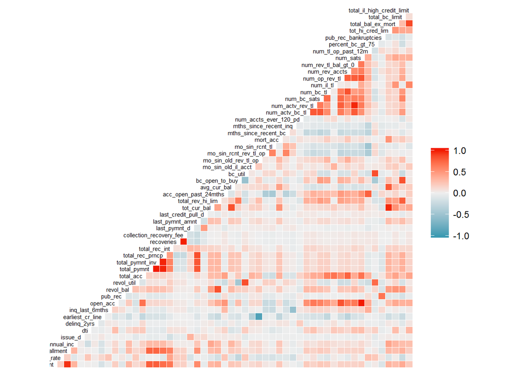

```r
# correlation eda -----------------------------------------------------------------------------


# str(dfs$train)

# visually inspect correlation across all variables
GGally::ggcorr(dfs$train, size = 2, hjust = 1)
```

```r
# extract higly correlated numeric variables
c_matrix <- cor(dfs$train %>% dplyr::select_if(is.numeric) %>% na.omit())

# caret's highly correlated function - gives index
high_cor <- findCorrelation(c_matrix, cutoff = .5)

# print highly correlated columns
names(dfs$train[,high_cor])
```

```
##  [1] "purpose"                 "num_actv_bc_tl"
##  [3] "delinq_2yrs"             "mths_since_recent_bc"
##  [5] "total_rec_prncp"         "mths_since_recent_inq"
##  [7] "num_rev_accts"           "mo_sin_rcnt_rev_tl_op"
##  [9] "mo_sin_rcnt_tl"          "loan_amnt"
## [11] "inq_last_6mths"          "earliest_cr_line"
## [13] "mo_sin_old_rev_tl_op"    "num_accts_ever_120_pd"
## [15] "open_acc"                "num_il_tl"
## [17] "int_rate"                "total_pymnt_inv"
## [19] "num_op_rev_tl"           "collection_recovery_fee"
## [21] "total_rec_int"           "num_actv_rev_tl"
## [23] "dti"                     "num_rev_tl_bal_gt_0"
## [25] "last_credit_pull_d"      "last_pymnt_d"
## [27] "tot_cur_bal"             "bc_open_to_buy"
## [29] "revol_util"              "title"
```

```r
# LVQ model -----------------------------------------------------------------------------------

# cross validation for LVQ model
control <- trainControl(method = 'cv', number = 3)

# lvq model - needed to randomly sample train to cut down on size fore presentation - not accurate
# should be training model on the full training set
lvq <- train(
  response ~ .,
  data = dfs$train %>% na.omit() %>% sample_frac(., .1),
  method = 'lvq',
  trControl = control
  )

# grab variable importance
(var_importance <- varImp(lvq))

# view results
plot(var_importance)
```

[output not shown]

### Predictive Modeling

Goal of this section is to fit two types of models, one for interpret-able inference, and one for pure predictive power. Both will be validated cross validation. Once final models are training, I will apply them each to the held out data to analyze the results. All results will be evaluated using the Kappa metric, which is a estimate of our model’s performance over the baseline accuracy of predicting the majority class.

The end result is a predictive model we can apply not only to the final validation set, but also the set of current loan holders to score them as a propensity to default.

Results were extremely positive for the simple generalized linear model and the random forest. These results are most likely be heavily biased by the limited rows used to build these models for presentation purposed. In practice I would should never cut down the number of rows to train our models on unless there was an absolute reason to.

Further exploratory data analysis and more robust modeling will be needed to make the final call on these predictive models.

```r
# parallel processing with caret --------------------------------------------------------------



cores <- detectCores()
cl <- makeCluster(cores[1] - 1)
registerDoParallel(cl)



# model preprocessing -------------------------------------------------------------------------

set.seed(854)

# center, scale, and impute missing data for final model
# process <- preProcess(dfs$train, method = c('scale', 'knnImpute'))
#
#
# # apply transformations to both train and test datasets
# dfs$train <- predict(process, dfs$train)
# dfs$test <- predict(process, dfs$test)
# dfs$validation <- predict(process, dfs$validation)


# three fold cv to cut down on time for presentation purposes - real cv could be 10 fold repeated
control <- trainControl(method = 'cv', number = 3, allowParallel=T)


# interpretable model -------------------------------------------------------------------------



set.seed(987)

# fit simple logistic regression on most important variables from EDA
glm_mod <- train(
  response ~
    last_pymnt_amnt +
    total_rec_prncp +
    total_pymnt +
    total_pymnt_inv +
    collection_recovery_fee +
    recoveries +
    int_rate    +
    last_pymnt_d +
    dti +
    bc_open_to_buy  +
    term +
    revol_util +
    bc_util +
    percent_bc_gt_75 +
    avg_cur_bal +
    tot_hi_cred_lim +
    mort_acc +
    num_rev_tl_bal_gt_0 +
    num_actv_rev_tl +
    total_rec_int,
  method = 'glm',
  family = 'binomial',
  metric = 'Kappa',
  data = dfs$train %>% na.omit() %>% sample_frac(., .1),
  trControl = control
)

# check cv summary of glm model
glm_mod
```

```
## Generalized Linear Model
##
## 7132 samples
##   20 predictor
##    2 classes: 'Default', 'Paid'
##
## No pre-processing
## Resampling: Cross-Validated (3 fold)
## Summary of sample sizes: 4755, 4754, 4755
## Resampling results:
##
##   Accuracy   Kappa
##   0.9934099  0.982932
```

```r
summary(glm_mod$finalModel)
```

```
##
## Call:
## NULL
##
## Deviance Residuals:
##    Min      1Q  Median      3Q     Max
## -5.885   0.000   0.000   0.000   2.998
##
## Coefficients:
##                               Estimate     Std. Error z value
## (Intercept)             -238.603604155   43.841541779  -5.442
## last_pymnt_amnt            0.003517860    0.000366020   9.611
## total_rec_prncp            0.073338565    0.023652611   3.101
## total_pymnt               -0.078921586    0.027533171  -2.866
## total_pymnt_inv            0.007705589    0.010406741   0.740
## collection_recovery_fee   -3.500136293  286.693207615  -0.012
## recoveries                 0.086573598   39.771555384   0.002
## int_rate                  42.058474018    5.322921139   7.901
## last_pymnt_d               0.005422657    0.001021858   5.307
## dti                       -0.022732526    0.020158692  -1.128
## bc_open_to_buy            -0.000075380    0.000018995  -3.968
## `term 60 months`           2.408631026    0.792062235   3.041
## revol_util                 0.641151396    1.113913892   0.576
## bc_util                   -0.001261794    0.012885899  -0.098
## percent_bc_gt_75           0.000137518    0.008154757   0.017
## avg_cur_bal               -0.000004337    0.000034626  -0.125
## tot_hi_cred_lim           -0.000001686    0.000003398  -0.496
## mort_acc                  -0.078195313    0.103401238  -0.756
## num_rev_tl_bal_gt_0        0.698651239    0.434068082   1.610
## num_actv_rev_tl           -0.753304834    0.424059516  -1.776
## total_rec_int              0.062972085    0.023453967   2.685
##                                     Pr(>|z|)
## (Intercept)              0.00000005256479725 ***
## last_pymnt_amnt         < 0.0000000000000002 ***
## total_rec_prncp                      0.00193 **
## total_pymnt                          0.00415 **
## total_pymnt_inv                      0.45903
## collection_recovery_fee              0.99026
## recoveries                           0.99826
## int_rate                 0.00000000000000276 ***
```

[output cut: 8 more lines]

```
## tot_hi_cred_lim                      0.61971
## mort_acc                             0.44951
## num_rev_tl_bal_gt_0                  0.10750
## num_actv_rev_tl                      0.07566 .
## total_rec_int                        0.00725 **
## ---
## Signif. codes:  0 '***' 0.001 '**' 0.01 '*' 0.05 '.' 0.1 ' ' 1
##
## (Dispersion parameter for binomial family taken to be 1)
##
##     Null deviance: 8194.27  on 7131  degrees of freedom
## Residual deviance:  276.02  on 7111  degrees of freedom
## AIC: 318.02
##
## Number of Fisher Scoring iterations: 23
```

```r
# apply model to test data - set classification threshold at .5
glm_pred <- predict(glm_mod, newdata = dfs$test %>% na.omit(), type = 'prob') %>%
  mutate(pred = ifelse(Paid >= .5, 'Paid', 'Default')) %>%
  mutate_if(is.character, as.factor)

# add predictions to the test data set
glm_test <- dfs$test %>% na.omit() %>% add_predictions(glm_mod)

# view confusion matrix
confusionMatrix(glm_test$pred, glm_test$response)
```

```
## Confusion Matrix and Statistics
##
##           Reference
## Prediction Default  Paid
##    Default    6122    99
##    Paid         82 17458
##
##                Accuracy : 0.9924
##                  95% CI : (0.9912, 0.9934)
##     No Information Rate : 0.7389
##     P-Value [Acc > NIR] : <0.0000000000000002
##
##                   Kappa : 0.9803
##  Mcnemar's Test P-Value : 0.2343
##
##             Sensitivity : 0.9868
##             Specificity : 0.9944
##          Pos Pred Value : 0.9841
##          Neg Pred Value : 0.9953
##              Prevalence : 0.2611
##          Detection Rate : 0.2576
##    Detection Prevalence : 0.2618
##       Balanced Accuracy : 0.9906
##
##        'Positive' Class : Default
##
```

```r
# predictive model ----------------------------------------------------------------------------

set.seed(987)

# fit flexible model for pure prediction power
# rf is non-parameteric and insensistive to scaling
rf_mod <- train(
  response ~
    last_pymnt_amnt +
    total_rec_prncp +
    total_pymnt +
    total_pymnt_inv +
    collection_recovery_fee +
    recoveries +
    int_rate    +
    last_pymnt_d +
    dti +
    bc_open_to_buy  +
    term +
    revol_util +
    bc_util +
    percent_bc_gt_75 +
    avg_cur_bal +
    tot_hi_cred_lim +
    mort_acc +
    num_rev_tl_bal_gt_0 +
    num_actv_rev_tl +
    total_rec_int,
  method = 'rf',
  metric = 'Kappa',
  data = dfs$train %>% na.omit() %>% sample_frac(., .1),
  trControl = control
)

# check cv summary of rf model including best tuned parameters
rf_mod$finalModel
```

```
##
## Call:
##  randomForest(x = x, y = y, mtry = param$mtry)
##                Type of random forest: classification
##                      Number of trees: 500
## No. of variables tried at each split: 11
##
##         OOB estimate of  error rate: 0.43%
## Confusion matrix:
##         Default Paid class.error
## Default    1846   18 0.009656652
## Paid         13 5255 0.002467730
```

```r
# apply model to test data - set classification threshold at .5
rf_pred <- predict(rf_mod, newdata = dfs$test %>% na.omit(), type = 'prob') %>%
  mutate(pred = ifelse(Paid >= .5, 'Paid', 'Default')) %>%
  mutate_if(is.character, as.factor)

# add predictions to the test data set
rf_test <- dfs$test %>% na.omit() %>% add_predictions(rf_mod)

# view confusion matrix
confusionMatrix(rf_test$pred, rf_test$response)
```

```
## Confusion Matrix and Statistics
##
##           Reference
## Prediction Default  Paid
##    Default    6134    33
##    Paid         70 17524
##
##                Accuracy : 0.9957
##                  95% CI : (0.9947, 0.9965)
##     No Information Rate : 0.7389
##     P-Value [Acc > NIR] : < 0.00000000000000022
##
##                   Kappa : 0.9887
##  Mcnemar's Test P-Value : 0.0003894
##
##             Sensitivity : 0.9887
##             Specificity : 0.9981
##          Pos Pred Value : 0.9946
##          Neg Pred Value : 0.9960
##              Prevalence : 0.2611
##          Detection Rate : 0.2582
##    Detection Prevalence : 0.2595
##       Balanced Accuracy : 0.9934
##
##        'Positive' Class : Default
##
```